# Statistical Analysis of Microbiome Data: A Practical Pipeline

2026-05-05

# 1 Overview

This report demonstrates a practical implementation of the analytical pipeline for 16S rRNA amplicon microbiome data. We work through a real-world datasets.

|  | Dataset | Source | Primary Question |
| --- | --- | --- | --- |
| **1** | `dietswap` | `microbiome` R package | Do gut microbial communities differ between African (AFR) and African American (AAM) populations? |

The `dietswap` dataset is a genus-level phyloseq object derived from 16S rRNA amplicon sequencing, matching the data type assumed throughout this course.

```r
# ── Core microbiome / phyloseq ──────────────────────────────────────────────
library(phyloseq)
library(microbiome)

# ── Tidyverse ───────────────────────────────────────────────────────────────
library(tidyverse)

# ── Community ecology ────────────────────────────────────────────────────────
library(vegan)

# ── Visualisation ───────────────────────────────────────────────────────────
library(ggplot2)
library(ggpubr)
library(pheatmap)
library(RColorBrewer)
library(patchwork)

# ── Differential abundance ───────────────────────────────────────────────────
library(DESeq2)
library(ANCOMBC)   # provides ancombc2()
library(ALDEx2)

# ── Compositional data ───────────────────────────────────────────────────────
library(compositions)  # for clr()

# ── Contaminant detection ────────────────────────────────────────────────────
library(decontam)
```

# 2 `dietswap` — African vs. African American Gut Microbiome

## 2.1 Study Objective

The `dietswap` dataset (O’Keefe et al., 2015, *Nature Communications*) contains gut microbiome profiles from 222 samples collected during a two-week dietary intervention in which rural Africans (AFR) and African Americans (AAM) swapped their typical diets. Here we focus on the **baseline comparison** (before any diet swap) to ask:

> **Does overall gut microbial community composition and the abundance of individual genera differ between AFR and AAM subjects at baseline?**

Hypotheses:

- H1 (alpha diversity): AFR subjects have higher alpha diversity than AAM.
- H2 (beta diversity): Community composition differs significantly between nationalities.
- H3 (DA): Specific genera are differentially abundant between AFR and AAM at baseline.

## 2.2 Data Loading

```r
data("dietswap", package = "microbiome")
ps <- dietswap

# Retain baseline timepoint only (timepoint == 1)
ps <- subset_samples(ps, timepoint == 1)

cat("Samples:", nsamples(ps), "\n")
```

```
## Samples: 38
```

```r
cat("Genera:", ntaxa(ps), "\n")
```

```
## Genera: 130
```

```r
cat("Sample variables:", paste(sample_variables(ps), collapse = ", "), "\n")
```

```
## Sample variables: subject, sex, nationality, group, sample, timepoint, timepoint.within.group, bmi_group
```

## 2.3 Pre-processing & Quality Control

### 2.3.1 Data Summary

```r
# Count table dimensions
otu  <- as.data.frame(otu_table(ps))   # genera x samples
meta <- as.data.frame(sample_data(ps))

cat("Feature (genus) × Sample matrix:", nrow(otu), "×", ncol(otu), "\n\n")
```

```
## Feature (genus) × Sample matrix: 130 × 38
```

```r
# Group sizes
table(meta$nationality)
```

```
##
## AAM AFR
##  21  17
```

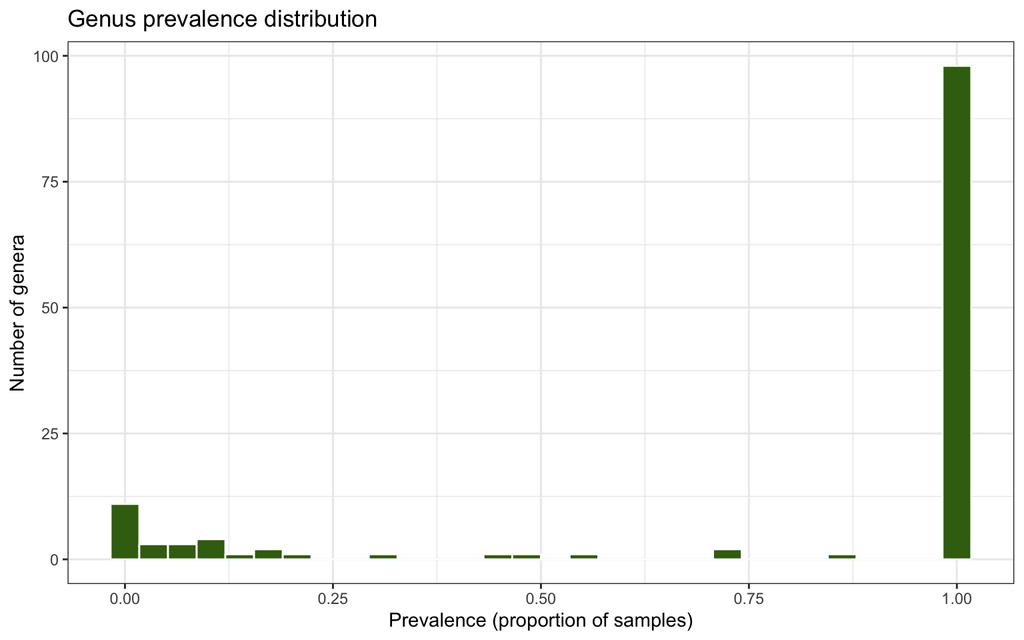

```r
# Prevalence: proportion of samples in which each genus is detected
prevalence <- rowSums(otu > 0) / ncol(otu)

prev_df <- data.frame(
  genus      = rownames(otu),
  prevalence = prevalence,
  mean_abund = rowMeans(otu)
)

ggplot(prev_df, aes(x = prevalence)) +
  geom_histogram(bins = 30, fill = "#3B6D11", colour = "white") +
  labs(title = "Genus prevalence distribution",
       x     = "Prevalence (proportion of samples)",
       y     = "Number of genera") +
  theme_bw()
```

**Interpretation:** The prevalence histogram reveals a strongly bimodal pattern. A moderate number of genera are detected in fewer than 10% of samples — these are rare, low-prevalence taxa that contribute minimal information to group-level analyses and inflate the multiple testing burden. A second cluster of genera is prevalent across the majority of samples (prevalence > 0.75), representing the core gut community consistently detected across individuals. The prevalence filter (see below) retaining only genera present in ≥ 10% of samples removes the first cluster and focuses subsequent analyses on the more informative core community.

### 2.3.2 Library Size Inspection

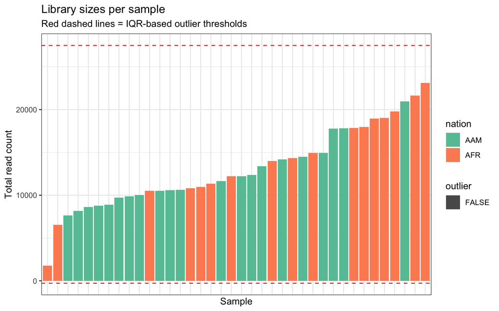

```r
lib_sizes <- sample_sums(ps)
lib_df    <- data.frame(
  sample    = names(lib_sizes),
  lib_size  = lib_sizes,
  nation    = meta$nationality
)

# Flag outliers using 1.5 × IQR rule
q1 <- quantile(lib_sizes, 0.25)
q3 <- quantile(lib_sizes, 0.75)
iqr_thresh_lo <- q1 - 1.5 * (q3 - q1)
iqr_thresh_hi <- q3 + 1.5 * (q3 - q1)

lib_df$outlier <- lib_df$lib_size < iqr_thresh_lo | lib_df$lib_size > iqr_thresh_hi

ggplot(lib_df, aes(x = reorder(sample, lib_size), y = lib_size,
                   fill = nation, colour = outlier)) +
  geom_bar(stat = "identity", linewidth = 0.4) +
  scale_colour_manual(values = c("FALSE" = NA, "TRUE" = "red"), na.value = NA) +
  scale_fill_brewer(palette = "Set2") +
  geom_hline(yintercept = c(iqr_thresh_lo, iqr_thresh_hi),
             linetype = "dashed", colour = "red", linewidth = 0.5) +
  labs(title = "Library sizes per sample",
       subtitle = "Red dashed lines = IQR-based outlier thresholds",
       x = "Sample", y = "Total read count") +
  theme_bw() +
  theme(axis.text.x = element_blank(), axis.ticks.x = element_blank())
```

```r
cat("Samples flagged as outliers:", sum(lib_df$outlier), "\n")
```

```
## Samples flagged as outliers: 0
```

**Interpretation:** Library sizes are broadly consistent across samples, ranging from approximately 1,700 to 23,000 reads, with no samples falling below the IQR-based lower threshold. No samples are flagged as outliers and none are removed at this stage. The moderate variability in sequencing depth across samples nonetheless motivates normalisation prior to comparative analyses.

### 2.3.3 Filtering

```r
# 1. Remove low-quality samples (below lower IQR threshold)
keep_samples <- lib_df$sample[!lib_df$outlier]
ps <- prune_samples(keep_samples, ps)

# 2. Prevalence filter: retain genera present in ≥ 10% of samples
ps <- filter_taxa(ps, function(x) sum(x > 0) / length(x) >= 0.10, prune = TRUE)

cat("After filtering — samples:", nsamples(ps),
    "| genera:", ntaxa(ps), "\n")
```

```
## After filtering — samples: 38 | genera: 113
```

### 2.3.4 Contaminant Assessment

```r
# Note: decontam requires negative control samples (isNeg = TRUE).
# The dietswap dataset does not include negative controls, so formal
# contaminant removal via decontam is not applicable here.
# In a real study with negative controls, you would run:
#
# sample_data(ps)$is_neg <- sample_data(ps)$sample_type == "negative_control"
# contamdf <- isContaminant(ps, method = "prevalence", neg = "is_neg")
# ps <- prune_taxa(!contamdf$contaminant, ps)
#
# We proceed without this step and note it as a limitation.
```

### 2.3.5 Abundance Distribution

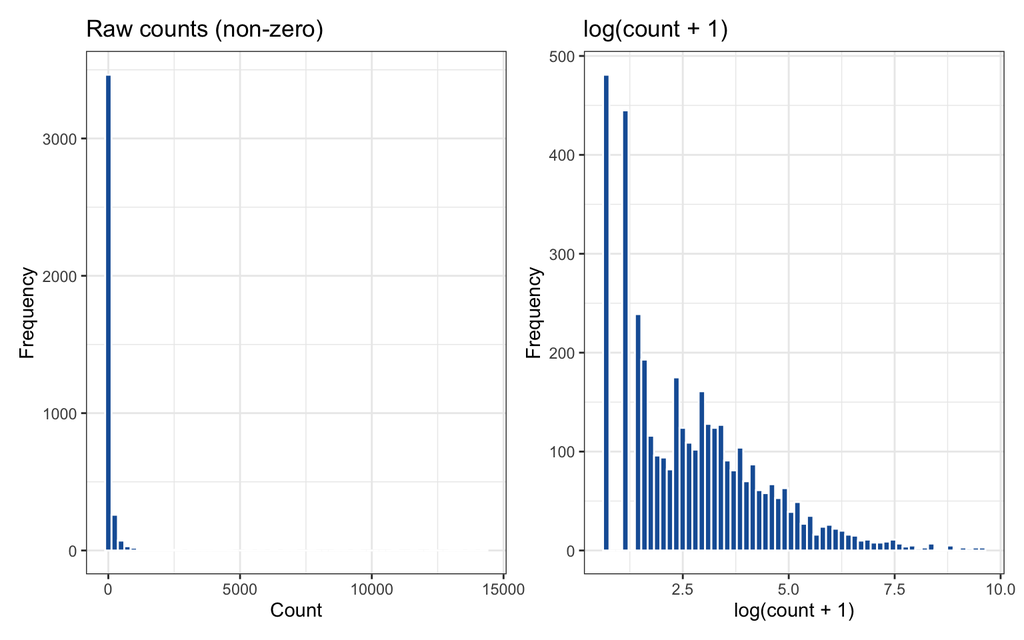

```r
count_vec <- as.vector(as.matrix(otu_table(ps)))
count_vec_nz <- count_vec[count_vec > 0]   # non-zero only

p1 <- ggplot(data.frame(x = count_vec_nz), aes(x = x)) +
  geom_histogram(bins = 60, fill = "#185FA5", colour = "white") +
  labs(title = "Raw counts (non-zero)", x = "Count", y = "Frequency") +
  theme_bw()

p2 <- ggplot(data.frame(x = log1p(count_vec_nz)), aes(x = x)) +
  geom_histogram(bins = 60, fill = "#185FA5", colour = "white") +
  labs(title = "log(count + 1)", x = "log(count + 1)", y = "Frequency") +
  theme_bw()

p1 + p2
```

**Interpretation:** Raw counts are highly right-skewed: the vast majority of non-zero entries are small, while a handful of dominant genera contribute disproportionately large counts. The log(count + 1) distribution remains noticeably right-skewed rather than symmetric, reflecting the overdispersed, zero-inflated nature of microbiome count data. This departure from normality reinforces the appropriateness of compositionally aware or count-based modelling approaches (e.g. ANCOM-BC2, DESeq2) rather than direct application of linear models to raw or log-transformed counts.

### 2.3.6 Abundance Visualisation

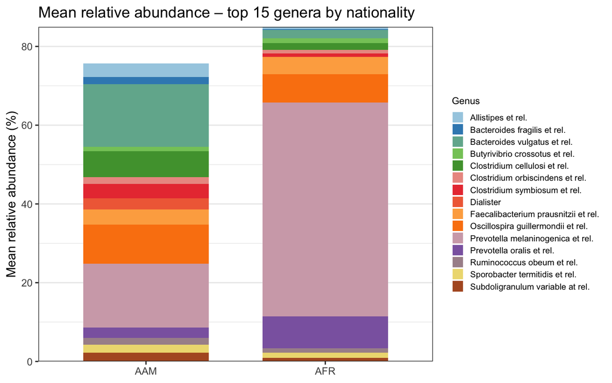

```r
# Top 15 genera by mean relative abundance
ps_rel <- transform_sample_counts(ps, function(x) x / sum(x))
top15  <- names(sort(taxa_sums(ps_rel), decreasing = TRUE))[1:15]
ps_top <- prune_taxa(top15, ps_rel)

# Melt to long format manually for full control over aesthetics
abund_df <- psmelt(ps_top) %>%
  dplyr::group_by(nationality, OTU) %>%
  dplyr::summarise(mean_abund = mean(Abundance) * 100, .groups = "drop") %>%
  dplyr::rename(Genus = OTU)

# Colour palette with enough distinct colours
genus_cols <- colorRampPalette(brewer.pal(12, "Paired"))(15)

ggplot(abund_df, aes(x = nationality, y = mean_abund, fill = Genus)) +
  geom_bar(stat = "identity", colour = NA, width = 0.7) +   # colour=NA removes black lines
  scale_fill_manual(values = genus_cols) +
  scale_y_continuous(expand = c(0, 0)) +
  labs(
    title = "Mean relative abundance – top 15 genera by nationality",
    x     = NULL,
    y     = "Mean relative abundance (%)"
  ) +
  theme_bw(base_size = 12) +
  theme(
    legend.key.size  = unit(0.4, "cm"),
    legend.text      = element_text(size = 8),
    legend.title     = element_text(size = 9),
    panel.grid.major.x = element_blank()
  ) +
  guides(fill = guide_legend(ncol = 1))
```

### 2.3.7 Collinearity: Genus–Genus Correlation Heatmap

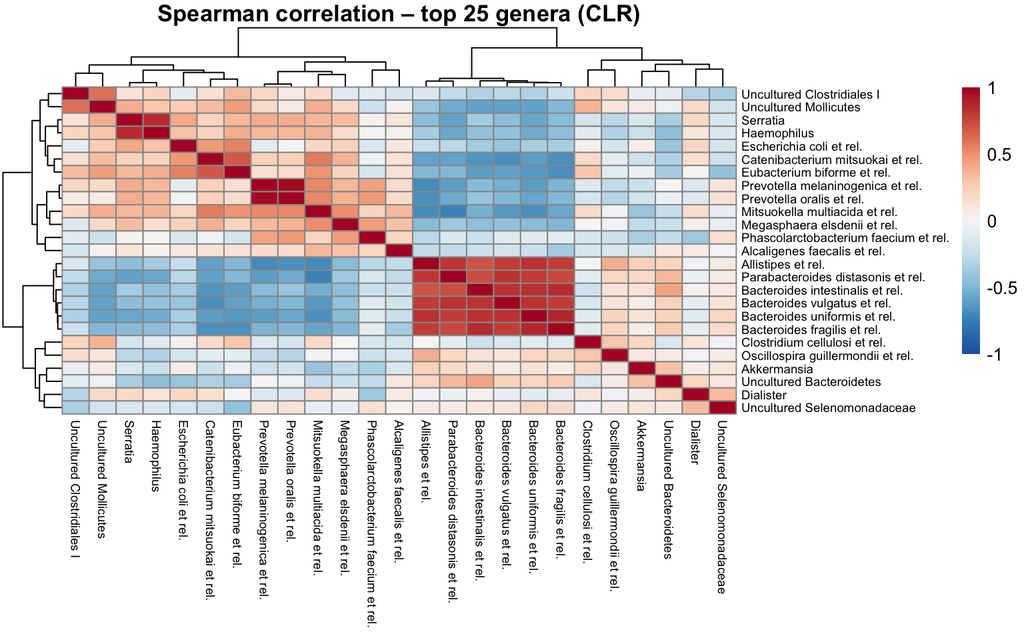

```r
# CLR-transformed abundance matrix for correlation
ps_clr <- microbiome::transform(ps, "clr")
clr_mat <- t(as.matrix(otu_table(ps_clr)))   # samples × genera

# Use top 25 genera (by variance) to keep heatmap legible
top25_var <- names(sort(apply(clr_mat, 2, var), decreasing = TRUE))[1:25]
cor_mat   <- cor(clr_mat[, top25_var], method = "spearman")

pheatmap(cor_mat,
         color            = colorRampPalette(rev(brewer.pal(9, "RdBu")))(100),
         breaks           = seq(-1, 1, length.out = 101),
         main             = "Spearman correlation – top 25 genera (CLR)",
         fontsize_row     = 7,
         fontsize_col     = 7,
         treeheight_row   = 30,
         treeheight_col   = 30)
```

**Interpretation:** Hierarchical clustering of the correlation matrix groups genera with similar abundance profiles. Strong positive clusters may reflect co-occurring ecological guilds; strong negative correlations are often artefacts of compositionality and should be interpreted cautiously even after CLR transformation.

## 2.4 Normalisation / Transformation

```r
# TSS: relative abundances
ps_tss <- transform_sample_counts(ps, function(x) x / sum(x))

# CLR transformation (handles zeros via the microbiome package's implementation)
ps_clr <- microbiome::transform(ps, "clr")

# Confirm
cat("CLR-transformed OTU table (first 3 genera, first 3 samples):\n")
```

```
## CLR-transformed OTU table (first 3 genera, first 3 samples):
```

```r
otu_table(ps_clr)[1:3, 1:3]
```

```
## OTU Table:          [3 taxa and 3 samples]
##                      taxa are rows
##                              Sample-32 Sample-33 Sample-34
## Akkermansia                   2.853744  3.615465  1.284828
## Alcaligenes faecalis et rel. -1.644251 -1.545830 -2.093388
## Allistipes et rel.            4.157182  2.836846  2.710607
```

## 2.5 Alpha Diversity

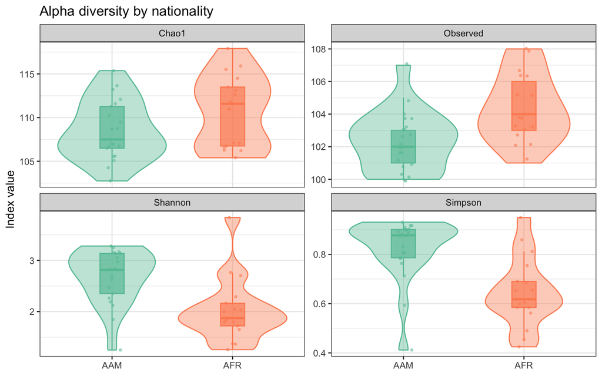

```r
# Compute on raw counts (not CLR)
alpha_df <- estimate_richness(ps,
              measures = c("Observed", "Chao1", "Shannon", "Simpson"))
alpha_df$nationality <- sample_data(ps)$nationality
alpha_df$sample      <- rownames(alpha_df)

# Reshape for plotting
alpha_long <- alpha_df %>%
  pivot_longer(cols      = c(Observed, Chao1, Shannon, Simpson),
               names_to  = "index",
               values_to = "value")

ggplot(alpha_long, aes(x = nationality, y = value,
                       fill = nationality, colour = nationality)) +
  geom_violin(alpha = 0.4, linewidth = 0.5) +
  geom_boxplot(width = 0.2, alpha = 0.7, outlier.shape = NA) +
  geom_jitter(width = 0.07, size = 0.8, alpha = 0.5) +
  facet_wrap(~index, scales = "free_y") +
  scale_fill_brewer(palette  = "Set2") +
  scale_colour_brewer(palette = "Set2") +
  labs(title = "Alpha diversity by nationality",
       x = NULL, y = "Index value") +
  theme_bw() +
  theme(legend.position = "none")
```

### 2.5.1 Statistical Test: Wilcoxon Rank-Sum

```r
indices <- c("Observed", "Chao1", "Shannon", "Simpson")

alpha_tests <- lapply(indices, function(idx) {
  afr <- alpha_long$value[alpha_long$nationality == "AFR" &
                          alpha_long$index == idx]   # from long form
  aam <- alpha_long$value[alpha_long$nationality == "AAM" &
                          alpha_long$index == idx]
  wt  <- wilcox.test(afr, aam)
  data.frame(index = idx, W = wt$statistic, p_value = wt$p.value)
})

alpha_results <- bind_rows(alpha_tests)
print(alpha_results)
```

```
##          index     W      p_value
## W...1 Observed 271.5 0.0059882006
## W...2    Chao1 233.0 0.1128337000
## W...3  Shannon  63.0 0.0004364324
## W...4  Simpson  61.0 0.0003353800
```

**Interpretation:** We test each alpha diversity index separately using the Wilcoxon rank-sum test.

## 2.6 Beta Diversity

### 2.6.1 Ordination (PCoA on Bray–Curtis)

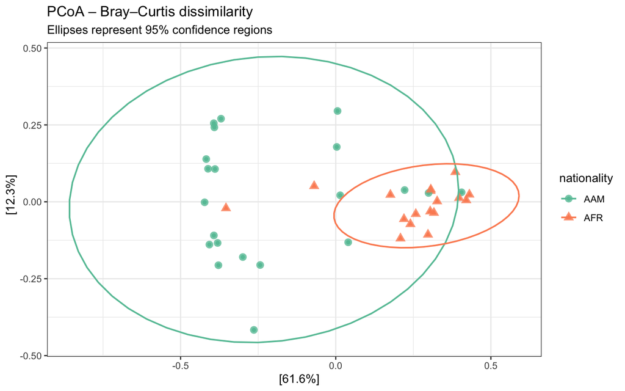

```r
ps_rai <- ps_tss   # relative abundances

ord <- ordinate(ps_rai, method = "PCoA", distance = "bray")

plot_ordination(ps_rai, ord, color = "nationality", shape = "nationality") +
  geom_point(size = 3, alpha = 0.8) +
  stat_ellipse(aes(group = nationality), level = 0.95, linewidth = 0.7) +
  scale_colour_brewer(palette = "Set2") +
  labs(title = "PCoA – Bray–Curtis dissimilarity",
       subtitle = "Ellipses represent 95% confidence regions") +
  theme_bw()
```

### 2.6.2 PERMANOVA

```r
bray_dist <- phyloseq::distance(ps_tss, method = "bray")
meta_sub   <- as(sample_data(ps_tss), "data.frame")

set.seed(42)
perm_res <- adonis2(bray_dist ~ nationality, data = meta_sub, permutations = 999)
print(perm_res)
```

```
## Permutation test for adonis under reduced model
## Permutation: free
## Number of permutations: 999
##
## adonis2(formula = bray_dist ~ nationality, data = meta_sub, permutations = 999)
##          Df SumOfSqs      R2     F Pr(>F)
## Model     1   1.8988 0.30205 15.58  0.001 ***
## Residual 36   4.3875 0.69795
## Total    37   6.2864 1.00000
## ---
## Signif. codes:  0 '***' 0.001 '**' 0.01 '*' 0.05 '.' 0.1 ' ' 1
```

PERMANOVA confirms that nationality explains a statistically significant and substantial proportion of the variance in community composition (R^2 = 0.302, F = 15.58, p = 0.001). Approximately 30% of the total between-sample dissimilarity is attributable to nationality, which is a large effect size in the context of human gut microbiome studies.

### 2.6.3 Homogeneity of Dispersion (PERMDISP)

```r
bd <- betadisper(bray_dist, meta_sub$nationality)
print(permutest(bd, permutations = 999))
```

```
##
## Permutation test for homogeneity of multivariate dispersions
## Permutation: free
## Number of permutations: 999
##
## Response: Distances
##           Df  Sum Sq Mean Sq      F N.Perm Pr(>F)
## Groups     1 0.38944 0.38944 20.085    999  0.001 ***
## Residuals 36 0.69804 0.01939
## ---
## Signif. codes:  0 '***' 0.001 '**' 0.01 '*' 0.05 '.' 0.1 ' ' 1
```

The test for homogeneity of within-group dispersion is also significant (F = 20.09, p = 0.001), indicating that the two groups differ not only in their community centroids but also in their within-group spread. AAM communities appear more variable (dispersed) around their group centroid than AFR communities. This means that the significant PERMANOVA result reflects a combination of centroid separation *and* dispersion differences — both components should be reported and acknowledged. Specifically, the greater homogeneity of AFR communities may itself be a biologically meaningful finding, suggesting that the traditional African diet structures the gut microbiome more consistently across individuals.

## 2.7 Differential Abundance Analysis

### 2.7.1 DESeq2

```r
# DESeq2 requires integer counts; use the raw (unfiltered-by-normalisation) ps
ds <- phyloseq_to_deseq2(ps, ~ nationality)
ds <- estimateSizeFactors(ds, type = "poscounts")  # handles zeros
ds <- DESeq(ds, test = "Wald", fitType = "parametric")

res_deseq <- results(ds, contrast = c("nationality", "AFR", "AAM"),
                     alpha = 0.05)
res_deseq_df <- as.data.frame(res_deseq) %>%
  rownames_to_column("genus") %>%
  arrange(padj)

cat("Significant genera (padj < 0.05):", sum(res_deseq_df$padj < 0.05, na.rm = TRUE), "\n")
```

```
## Significant genera (padj < 0.05): 41
```

```r
head(res_deseq_df[!is.na(res_deseq_df$padj) & res_deseq_df$padj < 0.05, ], 10)
```

```
##                                 genus   baseMean log2FoldChange     lfcSE
## 1       Bacteroides uniformis et rel.   70.72943      -4.027683 0.4733096
## 2        Bacteroides fragilis et rel.  136.92419      -2.973845 0.3786477
## 3  Parabacteroides distasonis et rel.   84.44759      -2.215824 0.3336955
## 4       Clostridium symbiosum et rel.  279.62311      -2.105709 0.3239657
## 5      Mitsuokella multiacida et rel.   28.42884       3.715050 0.6126162
## 6    Bacteroides intestinalis et rel.   11.54643      -3.009453 0.5028038
## 7          Bacteroides ovatus et rel.   78.26341      -2.078822 0.3476827
## 8                  Allistipes et rel.  227.90377      -2.444038 0.4149103
## 9        Bacteroides vulgatus et rel. 1100.93196      -2.831868 0.4922139
## 10      Bacteroides stercoris et rel.   26.97528      -2.085150 0.3847851
##         stat       pvalue         padj
## 1  -8.509616 1.745108e-17 1.919619e-15
## 2  -7.853857 4.034338e-15 2.218886e-13
## 3  -6.640258 3.131344e-11 1.148159e-09
## 4  -6.499789 8.043271e-11 2.211900e-09
## 5   6.064237 1.325817e-09 2.916797e-08
## 6  -5.985344 2.159331e-09 3.526327e-08
## 7  -5.979079 2.244026e-09 3.526327e-08
## 8  -5.890521 3.849791e-09 5.293463e-08
## 9  -5.753327 8.750411e-09 1.069495e-07
## 10 -5.418998 5.993396e-08 6.195881e-07
```

### 2.7.2 Volcano Plot

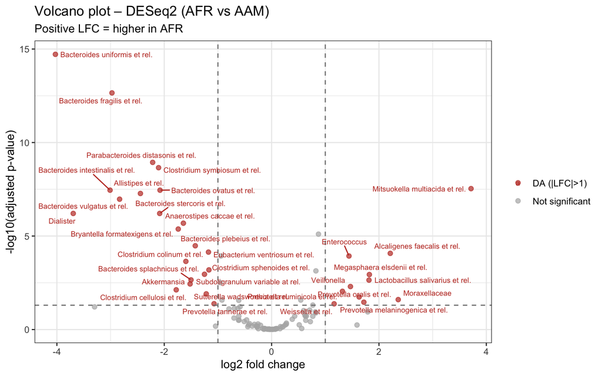

```r
res_deseq_df %>%
  filter(!is.na(padj)) %>%
  mutate(sig = ifelse(padj < 0.05 & abs(log2FoldChange) > 1,
                      "DA (|LFC|>1)", "Not significant")) %>%
  ggplot(aes(x = log2FoldChange, y = -log10(padj), colour = sig)) +
  geom_point(alpha = 0.7, size = 1.8) +
  geom_vline(xintercept = c(-1, 1), linetype = "dashed", colour = "grey50") +
  geom_hline(yintercept = -log10(0.05), linetype = "dashed", colour = "grey50") +
  scale_colour_manual(values = c("DA (|LFC|>1)" = "#C0392B",
                                 "Not significant" = "grey70")) +
  ggrepel::geom_text_repel(
    data = . %>% filter(sig == "DA (|LFC|>1)"),
    aes(label = genus), size = 2.5, max.overlaps = 15) +
  labs(title    = "Volcano plot – DESeq2 (AFR vs AAM)",
       subtitle = "Positive LFC = higher in AFR",
       x = "log2 fold change", y = "-log10(adjusted p-value)",
       colour = NULL) +
  theme_bw()
```

The volcano plot visually corroborates these findings: the left quadrant (higher in AAM) is dominated by *Bacteroides* taxa, while the right quadrant (higher in AFR) features *Prevotella* and *Mitsuokella* genera. Highly significant hits cluster away from the horizontal FDR threshold line, indicating robust signals.

### 2.7.3 ANCOM-BC2 (Compositionally Aware)

```r
ancom_res <- ancombc2(
  data     = ps,
  tax_level = NULL,           # genus level already
  fix_formula = "nationality",
  p_adj_method = "BH",
  alpha = 0.05
)

ancom_df <- ancom_res$res %>%
  filter(diff_nationalityAFR == TRUE) %>%
  dplyr::select(taxon, lfc_nationalityAFR, p_nationalityAFR, q_nationalityAFR) %>%
  dplyr::rename(genus = taxon, LFC = lfc_nationalityAFR,
         p_val = p_nationalityAFR, q_val = q_nationalityAFR) %>%
  arrange(q_val)

cat("ANCOM-BC2 significant genera:", nrow(ancom_df), "\n")
```

```
## ANCOM-BC2 significant genera: 26
```

```r
head(ancom_df, 10)
```

```
##                                 genus       LFC        p_val        q_val
## 1       Bacteroides uniformis et rel. -2.580434 7.147676e-08 5.209222e-06
## 2      Mitsuokella multiacida et rel.  2.912944 9.219862e-08 5.209222e-06
## 3                  Allistipes et rel. -1.822454 8.277544e-07 1.558937e-05
## 4        Bacteroides fragilis et rel. -1.725001 6.606065e-07 1.558937e-05
## 5        Bacteroides vulgatus et rel. -2.341758 4.572607e-07 1.558937e-05
## 6  Parabacteroides distasonis et rel. -1.570333 7.650718e-07 1.558937e-05
## 7          Bacteroides ovatus et rel. -1.489806 1.811547e-06 2.924355e-05
## 8       Clostridium symbiosum et rel. -1.218318 1.058162e-05 1.494654e-04
## 9   Prevotella melaninogenica et rel.  2.972439 2.512122e-05 3.154109e-04
## 10   Bacteroides intestinalis et rel. -1.571224 4.030605e-05 4.554584e-04
```

ANCOM-BC2, which explicitly corrects for compositional bias, identified **26 significantly differentially abundant genera** — a more conservative count than DESeq2’s 41. The top hits are directionally consistent with DESeq2: multiple *Bacteroides* taxa are enriched in AAM (negative LFC), while *Mitsuokella multiacida* and *Prevotella melaninogenica* are enriched in AFR (positive LFC).

### 2.7.4 Comparing DESeq2 and ANCOM-BC2

```r
da_deseq  <- res_deseq_df$genus[!is.na(res_deseq_df$padj) & res_deseq_df$padj < 0.05]
da_ancom  <- ancom_df$genus

overlap   <- intersect(da_deseq, da_ancom)
cat("DESeq2 hits:", length(da_deseq),
    "| ANCOM-BC2 hits:", length(da_ancom),
    "| Overlap:", length(overlap), "\n")
```

```
## DESeq2 hits: 41 | ANCOM-BC2 hits: 26 | Overlap: 25
```

```r
cat("Concordant genera:\n"); print(overlap)
```

```
## Concordant genera:
```

```
##  [1] "Bacteroides uniformis et rel."      "Bacteroides fragilis et rel."
##  [3] "Parabacteroides distasonis et rel." "Clostridium symbiosum et rel."
##  [5] "Mitsuokella multiacida et rel."     "Bacteroides intestinalis et rel."
##  [7] "Bacteroides ovatus et rel."         "Allistipes et rel."
##  [9] "Bacteroides vulgatus et rel."       "Bacteroides stercoris et rel."
## [11] "Anaerostipes caccae et rel."        "Bryantella formatexigens et rel."
## [13] "Clostridium difficile et rel."      "Bacteroides plebeius et rel."
## [15] "Eubacterium ventriosum et rel."     "Tannerella et rel."
## [17] "Clostridium sphenoides et rel."     "Subdoligranulum variable at rel."
## [19] "Megasphaera elsdenii et rel."       "Bacteroides splachnicus et rel."
## [21] "Ruminococcus gnavus et rel."        "Prevotella ruminicola et rel."
## [23] "Prevotella oralis et rel."          "Prevotella melaninogenica et rel."
## [25] "Collinsella"
```

**Interpretation:** Genera appearing as significant in both DESeq2 and ANCOM-BC2 are the most credible candidates, as they are robust to differences in methodological assumptions. Hits unique to one method should be treated with more caution and noted as exploratory.

**Method comparison:**

- **25 of the 26 ANCOM-BC2 hits** are also significant in DESeq2 (96% concordance from ANCOM-BC2’s perspective), providing strong cross-method validation for these genera.
- DESeq2 identified 16 additional genera not flagged by ANCOM-BC2. These may represent true positives that ANCOM-BC2’s more conservative correction misses, or they may be false positives driven by DESeq2’s imperfect handling of compositionality. They should be treated as exploratory findings pending replication.
- The 25 concordant genera — including *Bacteroides uniformis*, *B. fragilis*, *B. vulgatus*, *Allistipes*, *Clostridium symbiosum*, *Prevotella* spp., and *Collinsella* — represent the most credible candidates for diet-driven microbial differences between AFR and AAM populations.

## 2.8 Correlation Analysis

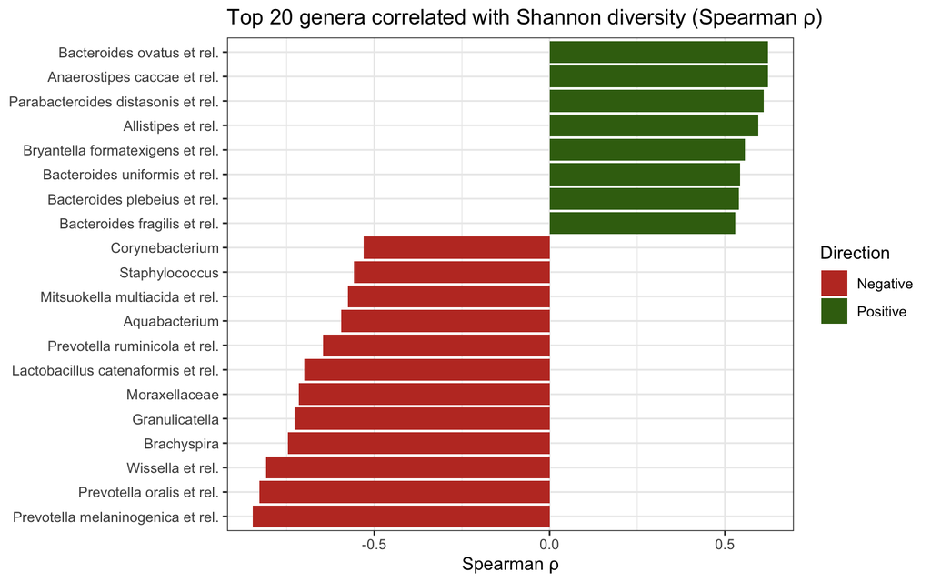

```r
# Correlate CLR-transformed genus abundances with Shannon diversity
clr_mat_samp <- t(as.matrix(otu_table(ps_clr)))   # samples × genera

alpha_df$sample <- gsub(".","-",alpha_df$sample, fixed=T)
shannon_vals <- alpha_df$Shannon[match(rownames(clr_mat_samp),
                                       alpha_df$sample)]

# Spearman correlation of each genus with Shannon
corr_shannon <- apply(clr_mat_samp, 2, function(g) {
  ct <- cor.test(g, shannon_vals, method = "spearman")
  data.frame(rho = ct$estimate, p = ct$p.value)
})
corr_df <- bind_rows(corr_shannon, .id = "genus")
corr_df$q <- p.adjust(corr_df$p, method = "BH")
corr_df   <- arrange(corr_df, q)

# Plot top 20 by |rho|
top20_corr <- corr_df %>% slice_max(abs(rho), n = 20)

ggplot(top20_corr, aes(x = reorder(genus, rho), y = rho,
                       fill = rho > 0)) +
  geom_col() +
  coord_flip() +
  scale_fill_manual(values = c("TRUE" = "#3B6D11", "FALSE" = "#C0392B"),
                    labels = c("Negative", "Positive")) +
  labs(title = "Top 20 genera correlated with Shannon diversity (Spearman ρ)",
       x = NULL, y = "Spearman ρ", fill = "Direction") +
  theme_bw()
```

**Interpretation:** Genera with high positive ρ contribute positively to overall community evenness — their higher abundance is associated with greater diversity. Genera with strong negative ρ tend to dominate in low-diversity samples, consistent with the role of bloom-forming taxa (e.g. *Prevotella* in some populations) in suppressing community evenness.